# Diagnostic Plot Gallery

Recognizing Good vs. Problematic Patterns in Longitudinal Models

## Introduction

Model diagnostics are essential for validating longitudinal models. This gallery provides side-by-side comparisons of **good** versus **problematic** patterns for each major diagnostic plot. Learning to recognize these patterns will help you identify model misspecification and guide remediation.

## 1. Residuals vs Fitted Values

This plot assesses whether the mean model is correctly specified and whether variance is constant (homoscedasticity).

### What to Look For

| Pattern | Interpretation | Action |
| --- | --- | --- |
| Random scatter around 0 | Good model fit | None needed |
| Funnel shape (fanning) | Heteroscedasticity | Add variance function or transform Y |
| Curved pattern | Mean model misspecification | Add polynomial terms or transform X |
| Clusters | Possible grouping structure | Consider group-specific effects |

### Simulated Examples

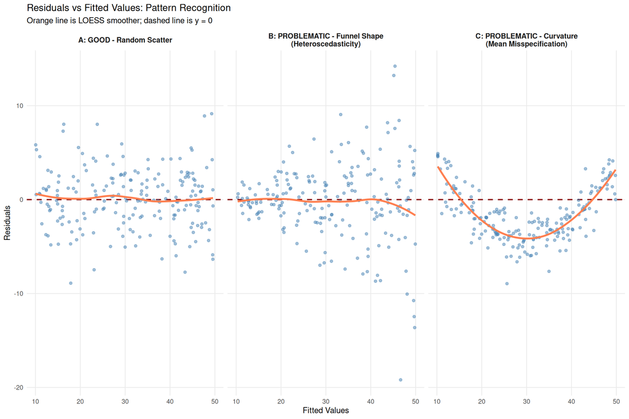

Figure 1: Residuals vs Fitted Values: Good vs Problematic Patterns

```r
# Simulate datasets with different characteristics
n <- 200

# Good: Random scatter
set.seed(667)
good_fitted <- runif(n, 10, 50)
good_resid <- rnorm(n, 0, 3)

# Problematic 1: Funnel shape (heteroscedasticity)
hetero_fitted <- runif(n, 10, 50)
hetero_resid <- rnorm(n, 0, 0.5 + 0.15 * (hetero_fitted - 10))

# Problematic 2: Curvature (mean model misspecification)
curve_fitted <- runif(n, 10, 50)
curve_resid <- 0.02 * (curve_fitted - 30)^2 - 4 + rnorm(n, 0, 1.5)

# Combine data
resid_fitted_data <- data.frame(
  Fitted = c(good_fitted, hetero_fitted, curve_fitted),
  Residual = c(good_resid, hetero_resid, curve_resid),
  Pattern = rep(c("A: GOOD - Random Scatter",
                  "B: PROBLEMATIC - Funnel Shape\n(Heteroscedasticity)",
                  "C: PROBLEMATIC - Curvature\n(Mean Misspecification)"), each = n)
)

# Create plot
ggplot(resid_fitted_data, aes(x = Fitted, y = Residual)) +
  geom_hline(yintercept = 0, linetype = "dashed", color = "darkred", linewidth = 0.8) +
  geom_point(alpha = 0.5, color = "steelblue") +
  geom_smooth(method = "loess", se = FALSE, color = "coral", linewidth = 1.2) +
  facet_wrap(~Pattern, ncol = 3) +
  labs(x = "Fitted Values",
       y = "Residuals",
       title = "Residuals vs Fitted Values: Pattern Recognition",
       subtitle = "Orange line is LOESS smoother; dashed line is y = 0") +
  theme_minimal(base_size = 11) +
  theme(strip.text = element_text(face = "bold", size = 10),
        panel.grid.minor = element_blank())
```

### Interpretation Guide

**Panel A (Good):**

- Points scatter randomly around the zero line
- LOESS smoother is approximately flat at 0
- Spread is constant across fitted values
- **Conclusion:** Mean model and variance assumptions are satisfied

**Panel B (Heteroscedasticity):**

- Funnel shape: spread increases with fitted values
- Common in count data or measurements with proportional error
- **Fix:** Use `weights = varPower()` or `varExp()` in nlme, or log-transform Y

**Panel C (Mean Misspecification):**

- Clear curved pattern in residuals
- LOESS smoother deviates substantially from zero
- **Fix:** Add quadratic term, use splines, or transform X

## 2. Residuals vs Time

This plot specifically examines whether the residual variance or correlation structure changes over time.

### What to Look For

| Pattern | Interpretation | Action |
| --- | --- | --- |
| Flat band, no trend | Good model fit | None needed |
| Fanning with time | Need random slopes or variance function | Add random slopes |
| Trend over time | Missing time effect in mean model | Add time term or interaction |
| Periodic pattern | Seasonal effects or cyclical correlation | Model seasonality |

### Simulated Examples

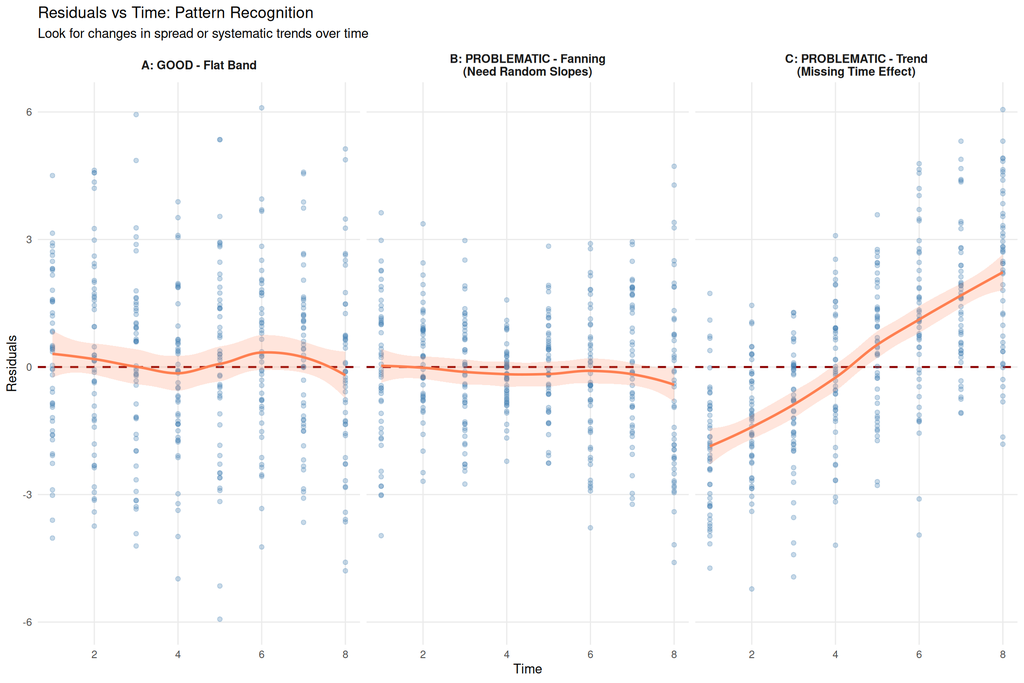

Figure 2: Residuals vs Time: Good vs Problematic Patterns

```r
# Simulate subject-level data over time
n_subj <- 50
n_time <- 8

# Create base data structure
base_data <- expand.grid(
  subject = 1:n_subj,
  time = 1:n_time
)

# Good: Flat band
set.seed(667)
good_time <- base_data |>
  mutate(
    resid = rnorm(n(), 0, 2),
    Pattern = "A: GOOD - Flat Band"
  )

# Problematic 1: Fanning (need random slopes)
set.seed(668)
fanning_time <- base_data |>
  group_by(subject) |>
  mutate(
    slope_effect = rnorm(1, 0, 0.5)[1],
    resid = slope_effect * (time - 4) + rnorm(n(), 0, 1),
    Pattern = "B: PROBLEMATIC - Fanning\n(Need Random Slopes)"
  ) |>
  ungroup()

# Problematic 2: Trend (missing time effect)
set.seed(669)
trend_time <- base_data |>
  mutate(
    resid = -2 + 0.5 * time + rnorm(n(), 0, 1.5),
    Pattern = "C: PROBLEMATIC - Trend\n(Missing Time Effect)"
  )

# Combine data
resid_time_data <- bind_rows(
  good_time |> select(subject, time, resid, Pattern),
  fanning_time |> select(subject, time, resid, Pattern),
  trend_time |> select(subject, time, resid, Pattern)
)

# Create plot
ggplot(resid_time_data, aes(x = time, y = resid)) +
  geom_hline(yintercept = 0, linetype = "dashed", color = "darkred", linewidth = 0.8) +
  geom_point(alpha = 0.3, color = "steelblue") +
  geom_smooth(method = "loess", se = TRUE, color = "coral", fill = "coral", alpha = 0.2) +
  facet_wrap(~Pattern, ncol = 3) +
  labs(x = "Time",
       y = "Residuals",
       title = "Residuals vs Time: Pattern Recognition",
       subtitle = "Look for changes in spread or systematic trends over time") +
  theme_minimal(base_size = 11) +
  theme(strip.text = element_text(face = "bold", size = 10),
        panel.grid.minor = element_blank())
```

### The Fanning Pattern in Detail

The “fanning” pattern (Panel B) is particularly important because it suggests **subject-specific slopes**:

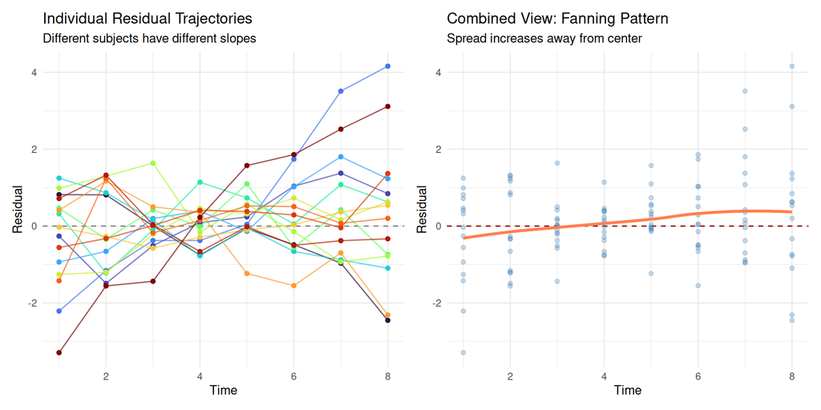

Figure 3: The Fanning Pattern: Why It Suggests Random Slopes

```r
# Show individual trajectories that create fanning
set.seed(667)
n_show <- 15

fanning_detail <- expand.grid(
  subject = 1:n_show,
  time = 1:n_time
) |>
  group_by(subject) |>
  mutate(
    true_slope = rnorm(1, 0, 0.6)[1],
    resid = true_slope * (time - 4) + rnorm(n(), 0, 0.5)
  ) |>
  ungroup()

p1 <- ggplot(fanning_detail, aes(x = time, y = resid, group = subject, color = factor(subject))) +
  geom_hline(yintercept = 0, linetype = "dashed", color = "gray50") +
  geom_line(alpha = 0.7) +
  geom_point(size = 1.5) +
  scale_color_viridis_d(option = "turbo") +
  labs(x = "Time", y = "Residual",
       title = "Individual Residual Trajectories",
       subtitle = "Different subjects have different slopes") +
  theme_minimal() +
  theme(legend.position = "none")

p2 <- ggplot(fanning_detail, aes(x = time, y = resid)) +
  geom_hline(yintercept = 0, linetype = "dashed", color = "darkred") +
  geom_point(alpha = 0.3, color = "steelblue") +
  geom_smooth(method = "loess", se = FALSE, color = "coral", linewidth = 1.2) +
  labs(x = "Time", y = "Residual",
       title = "Combined View: Fanning Pattern",
       subtitle = "Spread increases away from center") +
  theme_minimal()

p1 + p2
```

**Diagnosis:** When residuals fan out from a central time point, subjects have heterogeneous slopes that are not captured by the model. Adding `random = ~ time | subject` allows each subject to have their own slope.

## 3. QQ Plot of Residuals

The QQ plot assesses the normality assumption for residual errors.

### What to Look For

| Pattern | Interpretation | Action |
| --- | --- | --- |
| Points on diagonal | Normality satisfied | None needed |
| S-shape | Heavy tails (outliers) | Identify outliers; robust methods |
| Curved (concave/convex) | Skewness | Transform Y; check for floor/ceiling effects |
| Stairstep pattern | Discrete outcomes | Consider GLMMs |

### Simulated Examples

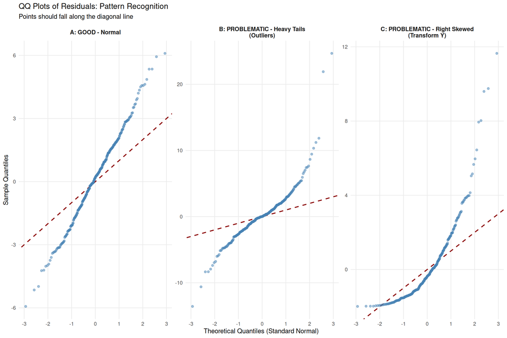

Figure 4: QQ Plots of Residuals: Good vs Problematic Patterns

```r
n_qq <- 300

# Good: Normal residuals
set.seed(667)
good_qq <- rnorm(n_qq, 0, 2)

# Problematic 1: Heavy tails
set.seed(668)
heavy_qq <- rt(n_qq, df = 3) * 2  # t-distribution with 3 df

# Problematic 2: Right skewed
set.seed(669)
skewed_qq <- rexp(n_qq, rate = 0.5) - 2  # Shifted exponential

# Function to create QQ data
create_qq_data <- function(x, label) {
  qq_obj <- qqnorm(x, plot.it = FALSE)
  data.frame(
    Theoretical = qq_obj$x,
    Sample = qq_obj$y,
    Pattern = label
  )
}

qq_data <- bind_rows(
  create_qq_data(good_qq, "A: GOOD - Normal"),
  create_qq_data(heavy_qq, "B: PROBLEMATIC - Heavy Tails\n(Outliers)"),
  create_qq_data(skewed_qq, "C: PROBLEMATIC - Right Skewed\n(Transform Y)")
)

# Create plot
ggplot(qq_data, aes(x = Theoretical, y = Sample)) +
  geom_abline(slope = 1, intercept = 0, linetype = "dashed", color = "darkred", linewidth = 0.8) +
  geom_point(alpha = 0.5, color = "steelblue") +
  facet_wrap(~Pattern, ncol = 3, scales = "free_y") +
  labs(x = "Theoretical Quantiles (Standard Normal)",
       y = "Sample Quantiles",
       title = "QQ Plots of Residuals: Pattern Recognition",
       subtitle = "Points should fall along the diagonal line") +
  theme_minimal(base_size = 11) +
  theme(strip.text = element_text(face = "bold", size = 10),
        panel.grid.minor = element_blank())
```

### Visual Interpretation Guide

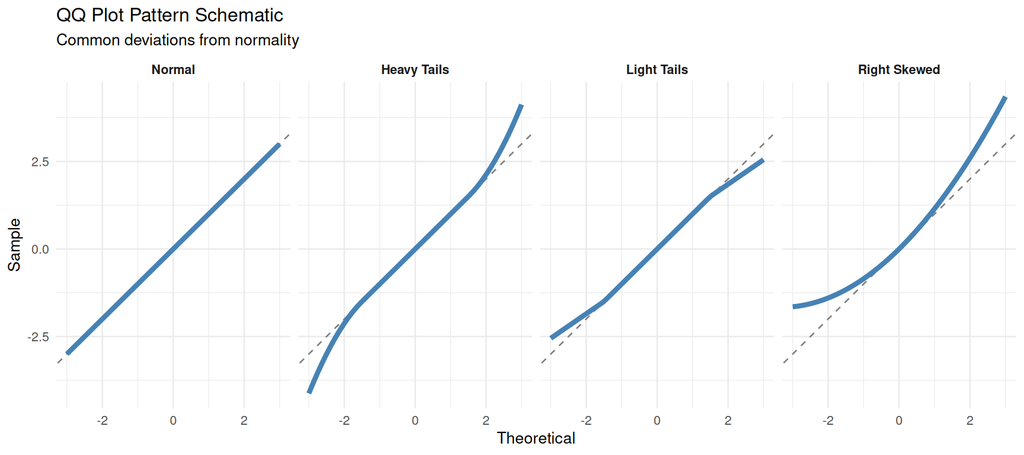

Figure 5: QQ Plot Interpretation Guide

## 4. QQ Plot of Random Effects

For mixed models, we also assess whether random effects are approximately normally distributed.

### What to Look For

| Pattern | Interpretation | Action |
| --- | --- | --- |
| Roughly on line | RE distribution OK | None needed |
| Moderate deviation | Often acceptable | Monitor; may be robust |
| Severe deviation | RE distribution misspecified | Try different RE structure; check data |
| Few extreme points | Influential subjects | Sensitivity analysis |

### Simulated Examples

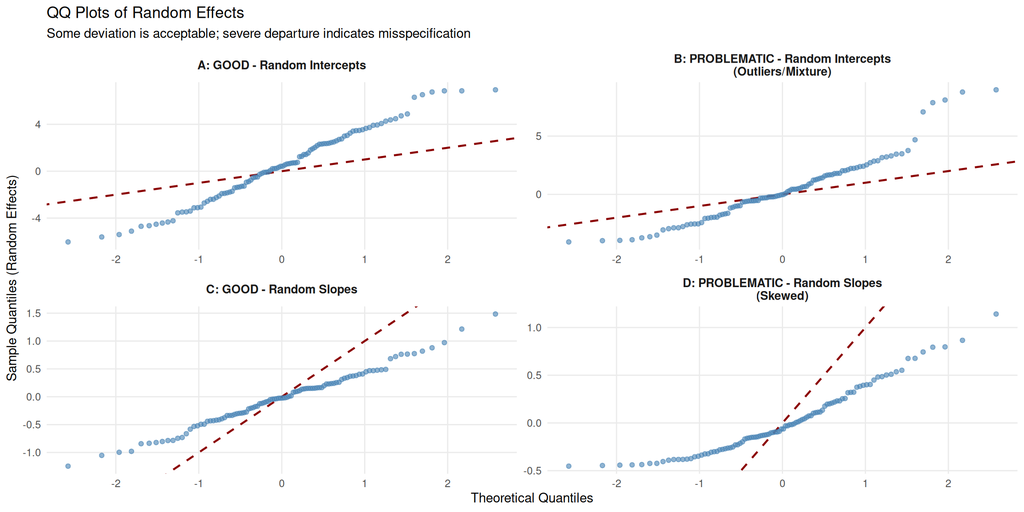

Figure 6: QQ Plots of Random Effects: Good vs Problematic

```r
# Simulate random intercepts and slopes
n_subj_re <- 100

# Good: Normal random effects
set.seed(667)
good_b0 <- rnorm(n_subj_re, 0, 3)
good_b1 <- rnorm(n_subj_re, 0, 0.5)

# Problematic: Non-normal random effects
set.seed(668)
bad_b0 <- c(rnorm(n_subj_re - 5, 0, 2), rnorm(5, 8, 1))  # With outliers
bad_b1 <- rbeta(n_subj_re, 2, 5) * 2 - 0.5  # Skewed

# Create QQ data for all
qq_re_data <- bind_rows(
  create_qq_data(good_b0, "A: GOOD - Random Intercepts"),
  create_qq_data(bad_b0, "B: PROBLEMATIC - Random Intercepts\n(Outliers/Mixture)"),
  create_qq_data(good_b1, "C: GOOD - Random Slopes"),
  create_qq_data(bad_b1, "D: PROBLEMATIC - Random Slopes\n(Skewed)")
)

ggplot(qq_re_data, aes(x = Theoretical, y = Sample)) +
  geom_abline(slope = 1, intercept = 0, linetype = "dashed", color = "darkred", linewidth = 0.8) +
  geom_point(alpha = 0.6, color = "steelblue") +
  facet_wrap(~Pattern, ncol = 2, scales = "free") +
  labs(x = "Theoretical Quantiles",
       y = "Sample Quantiles (Random Effects)",
       title = "QQ Plots of Random Effects",
       subtitle = "Some deviation is acceptable; severe departure indicates misspecification") +
  theme_minimal(base_size = 11) +
  theme(strip.text = element_text(face = "bold", size = 10),
        panel.grid.minor = element_blank())
```

### Practical Considerations

- Random effect normality is often less critical than residual normality
- With few subjects (< 30), QQ plots have high variability—be cautious about over-interpretation
- Severe non-normality may indicate latent subgroups (consider mixture models)
- Outlying random effects identify subjects requiring closer examination

## 5. Semivariogram

The semivariogram assesses whether the correlation structure is properly modeled. For detailed coverage, see the **Semivariogram Guide** handout.

### What to Look For

| Pattern | Interpretation | Action |
| --- | --- | --- |
| Flat near 1 | Correlation well-modeled | None needed |
| Rising toward 1 | Positive correlation not captured | Add AR(1) or similar |
| Above 1 at early lags | Negative correlation | Check for over-differencing |
| Different by group | Heterogeneous correlation | Group-specific structures |

### Simulated Examples

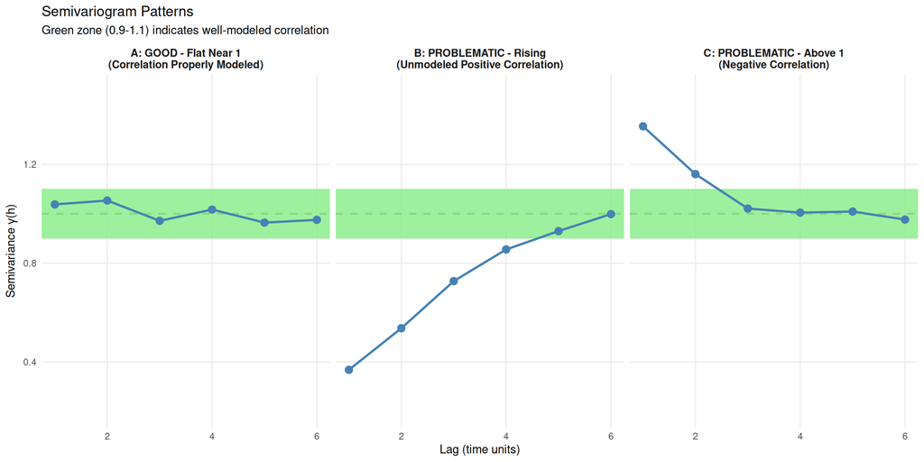

Figure 7: Semivariogram Patterns: Good vs Problematic

```r
# Create semivariogram data for different scenarios
lag <- 1:6

# Good: Flat at 1 (correlation properly modeled)
good_vario <- data.frame(
  lag = lag,
  gamma = c(0.98, 1.02, 0.97, 1.01, 0.99, 1.00) + rnorm(6, 0, 0.03),
  Pattern = "A: GOOD - Flat Near 1\n(Correlation Properly Modeled)"
)

# Problematic 1: Rising (positive correlation not captured)
rising_vario <- data.frame(
  lag = lag,
  gamma = c(0.35, 0.55, 0.72, 0.85, 0.93, 0.98) + rnorm(6, 0, 0.02),
  Pattern = "B: PROBLEMATIC - Rising\n(Unmodeled Positive Correlation)"
)

# Problematic 2: Above 1 (negative correlation)
above_vario <- data.frame(
  lag = lag,
  gamma = c(1.35, 1.15, 1.05, 1.02, 1.00, 0.99) + rnorm(6, 0, 0.02),
  Pattern = "C: PROBLEMATIC - Above 1\n(Negative Correlation)"
)

vario_data <- bind_rows(good_vario, rising_vario, above_vario)

ggplot(vario_data, aes(x = lag, y = gamma)) +
  geom_hline(yintercept = 1, linetype = "dashed", color = "darkred", linewidth = 0.8) +
  geom_rect(aes(xmin = -Inf, xmax = Inf, ymin = 0.9, ymax = 1.1),
            fill = "lightgreen", alpha = 0.3) +
  geom_point(color = "steelblue", size = 3) +
  geom_line(color = "steelblue", linewidth = 1) +
  facet_wrap(~Pattern, ncol = 3) +
  scale_y_continuous(limits = c(0.2, 1.5)) +
  labs(x = "Lag (time units)",
       y = expression(paste("Semivariance ", gamma, "(h)")),
       title = "Semivariogram Patterns",
       subtitle = "Green zone (0.9-1.1) indicates well-modeled correlation") +
  theme_minimal(base_size = 11) +
  theme(strip.text = element_text(face = "bold", size = 10),
        panel.grid.minor = element_blank())
```

### Connection to ACF

The semivariogram and ACF are related by: $\gamma(h) \approx 1 - \rho(h)$ for normalized residuals.

| Semivariogram | ACF | Interpretation |
| --- | --- | --- |
| $\gamma(h) < 1$ | $\rho(h) > 0$ | Positive correlation |
| $\gamma(h) = 1$ | $\rho(h) = 0$ | No correlation |
| $\gamma(h) > 1$ | $\rho(h) < 0$ | Negative correlation |

## 6. ACF of Residuals

The autocorrelation function (ACF) directly shows correlation at each lag.

### What to Look For

| Pattern | Interpretation | Action |
| --- | --- | --- |
| All within blue bands | No significant autocorrelation | None needed |
| Significant positive at lag 1 | AR(1) correlation | Add `corAR1()` |
| Slow decay | Strong serial correlation | AR(1) or random slopes |
| Alternating signs | Negative correlation pattern | Check model specification |

### Simulated Examples

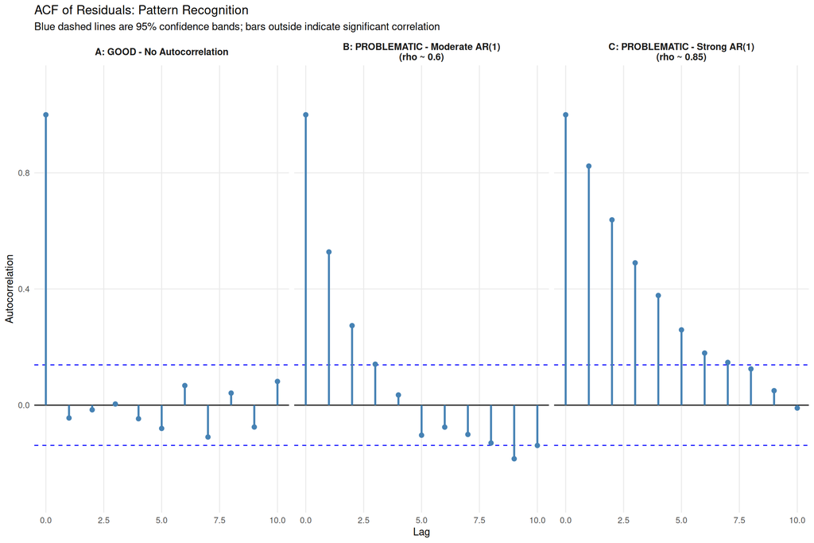

Figure 8: ACF Patterns: Good vs Problematic

```r
# Simulate residual series with different correlation structures
n_acf <- 200

# Good: No autocorrelation
set.seed(667)
good_acf_data <- rnorm(n_acf)

# Problematic: AR(1) correlation
set.seed(668)
ar1_acf_data <- arima.sim(n = n_acf, list(ar = 0.6))

# Problematic: Strong AR(1)
set.seed(669)
strong_ar1_data <- arima.sim(n = n_acf, list(ar = 0.85))

# Calculate ACF values
acf_good <- acf(good_acf_data, plot = FALSE, lag.max = 10)
acf_ar1 <- acf(ar1_acf_data, plot = FALSE, lag.max = 10)
acf_strong <- acf(strong_ar1_data, plot = FALSE, lag.max = 10)

# Create data frame
acf_plot_data <- data.frame(
  Lag = rep(0:10, 3),
  ACF = c(acf_good$acf, acf_ar1$acf, acf_strong$acf),
  Pattern = rep(c("A: GOOD - No Autocorrelation",
                  "B: PROBLEMATIC - Moderate AR(1)\n(rho ~ 0.6)",
                  "C: PROBLEMATIC - Strong AR(1)\n(rho ~ 0.85)"), each = 11)
)

# Confidence bounds (approximate)
ci_bound <- qnorm(0.975) / sqrt(n_acf)

ggplot(acf_plot_data, aes(x = Lag, y = ACF)) +
  geom_hline(yintercept = 0, color = "black") +
  geom_hline(yintercept = c(-ci_bound, ci_bound), linetype = "dashed", color = "blue") +
  geom_segment(aes(x = Lag, xend = Lag, y = 0, yend = ACF), color = "steelblue", linewidth = 1) +
  geom_point(color = "steelblue", size = 2) +
  facet_wrap(~Pattern, ncol = 3) +
  scale_y_continuous(limits = c(-0.3, 1.1)) +
  labs(x = "Lag",
       y = "Autocorrelation",
       title = "ACF of Residuals: Pattern Recognition",
       subtitle = "Blue dashed lines are 95% confidence bands; bars outside indicate significant correlation") +
  theme_minimal(base_size = 11) +
  theme(strip.text = element_text(face = "bold", size = 10),
        panel.grid.minor = element_blank())
```

### Interpreting Lag Structure

Table 1: ACF Pattern Interpretation Guide

| Lag Pattern | Interpretation | Suggested Fix |
| --- | --- | --- |
| Lag 1 only significant | Simple AR(1) correlation | Add corAR1() |
| Lags 1-2 significant, decay | AR(1) may be adequate; consider AR(2) | Add corAR1() or corARMA(p=2) |
| Slow decay across many lags | Strong serial dependence; random slopes may help | Add random slopes or higher-order AR |
| Lag 1 negative | Over-differencing or sign error | Check mean model specification |
| Oscillating pattern | Seasonal or cyclical effects | Model seasonality explicitly |

## 7. Influence Diagnostics

Influence diagnostics identify observations or subjects that have disproportionate impact on model estimates.

### Key Measures

| Measure | Formula Concept | Interpretation |
| --- | --- | --- |
| Cook’s Distance | Change in all coefficients when observation deleted | Overall influence |
| DFBETAS | Change in specific coefficient when observation deleted | Coefficient-specific influence |
| Leverage | Diagonal of hat matrix | Potential for influence |
| Studentized Residuals | Residuals scaled by their SE | Outlier detection |

### Simulated Example

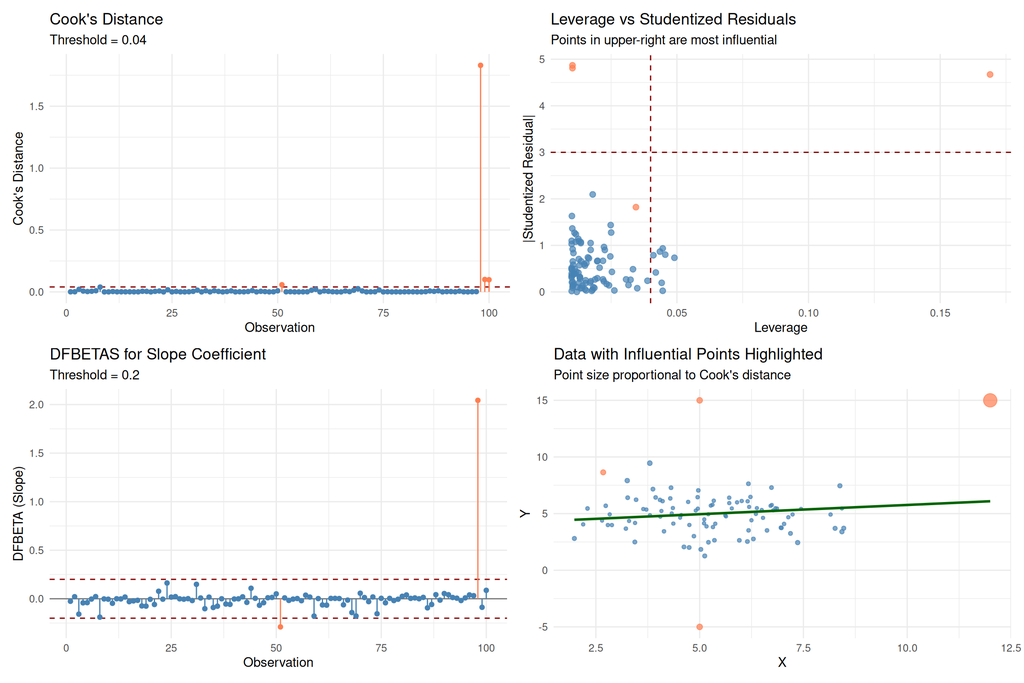

Figure 9: Influence Diagnostics: Identifying Problematic Observations

```r
# Create data with some influential points
set.seed(667)
n_inf <- 100

influence_data <- data.frame(
  x = c(rnorm(n_inf - 3, 5, 1.5), 12, 5, 5),      # 3 special points
  y = c(rnorm(n_inf - 3, 5, 1.5), 15, 15, -5)     # High leverage, outlier, both
)

# Fit model
fit_inf <- lm(y ~ x, data = influence_data)

# Calculate diagnostics
influence_data$cooks_d <- cooks.distance(fit_inf)
influence_data$leverage <- hatvalues(fit_inf)
influence_data$studentized <- rstudent(fit_inf)
influence_data$dfbeta_intercept <- dfbetas(fit_inf)[, 1]
influence_data$dfbeta_slope <- dfbetas(fit_inf)[, 2]
influence_data$obs <- 1:nrow(influence_data)

# Thresholds
cooks_threshold <- 4 / n_inf
leverage_threshold <- 2 * 2 / n_inf  # 2p/n
dfbeta_threshold <- 2 / sqrt(n_inf)

# Identify influential points
influence_data$influential <- with(influence_data,
  cooks_d > cooks_threshold | abs(studentized) > 3 |
  abs(dfbeta_slope) > dfbeta_threshold)

# Create plots
p1 <- ggplot(influence_data, aes(x = obs, y = cooks_d)) +
  geom_hline(yintercept = cooks_threshold, linetype = "dashed", color = "darkred") +
  geom_segment(aes(x = obs, xend = obs, y = 0, yend = cooks_d),
               color = ifelse(influence_data$cooks_d > cooks_threshold, "coral", "steelblue")) +
  geom_point(color = ifelse(influence_data$cooks_d > cooks_threshold, "coral", "steelblue")) +
  labs(x = "Observation", y = "Cook's Distance",
       title = "Cook's Distance",
       subtitle = paste("Threshold =", round(cooks_threshold, 3))) +
  theme_minimal()

p2 <- ggplot(influence_data, aes(x = leverage, y = abs(studentized))) +
  geom_hline(yintercept = 3, linetype = "dashed", color = "darkred") +
  geom_vline(xintercept = leverage_threshold, linetype = "dashed", color = "darkred") +
  geom_point(aes(color = influential), size = 2, alpha = 0.7) +
  scale_color_manual(values = c("FALSE" = "steelblue", "TRUE" = "coral")) +
  labs(x = "Leverage", y = "|Studentized Residual|",
       title = "Leverage vs Studentized Residuals",
       subtitle = "Points in upper-right are most influential") +
  theme_minimal() +
  theme(legend.position = "none")

p3 <- ggplot(influence_data, aes(x = obs, y = dfbeta_slope)) +
  geom_hline(yintercept = c(-dfbeta_threshold, dfbeta_threshold),
             linetype = "dashed", color = "darkred") +
  geom_hline(yintercept = 0, color = "gray50") +
  geom_segment(aes(x = obs, xend = obs, y = 0, yend = dfbeta_slope),
               color = ifelse(abs(influence_data$dfbeta_slope) > dfbeta_threshold, "coral", "steelblue")) +
  geom_point(color = ifelse(abs(influence_data$dfbeta_slope) > dfbeta_threshold, "coral", "steelblue")) +
  labs(x = "Observation", y = "DFBETA (Slope)",
       title = "DFBETAS for Slope Coefficient",
       subtitle = paste("Threshold =", round(dfbeta_threshold, 3))) +
  theme_minimal()

p4 <- ggplot(influence_data, aes(x = x, y = y)) +
  geom_point(aes(color = influential, size = cooks_d), alpha = 0.7) +
  geom_smooth(method = "lm", se = FALSE, color = "darkgreen", linewidth = 1) +
  scale_color_manual(values = c("FALSE" = "steelblue", "TRUE" = "coral")) +
  scale_size_continuous(range = c(1, 5)) +
  labs(x = "X", y = "Y",
       title = "Data with Influential Points Highlighted",
       subtitle = "Point size proportional to Cook's distance") +
  theme_minimal() +
  theme(legend.position = "none")

(p1 + p2) / (p3 + p4)
```

### Threshold Guidelines

| Measure | Common Threshold | Notes |
| --- | --- | --- |
| Cook’s Distance | $> 4/n$ or $> 1$ | $4/n$ more sensitive |
| DFBETAS | $> 2/\sqrt{n}$ | Per coefficient |
| Leverage | $> 2p/n$ | $p$ = number of parameters |
| Studentized Residual | $> 3$ | Outlier in Y |

### What to Do with Influential Points

1. **Verify data:** Check for data entry errors or measurement problems
2. **Understand the science:** Is this point scientifically plausible?
3. **Sensitivity analysis:** Fit with and without the point; compare conclusions
4. **Report transparently:** If excluding, justify and report both analyses
5. **Never delete just because it is influential**—only if there is a scientific reason

## 8. Complete Example: Diagnosis and Remediation

Let us work through a complete example where we identify problems and fix them.

### Simulate Data with Known Problems

```r
set.seed(667)

# Parameters
n_subjects <- 50
n_times <- 6

# Create data with multiple issues:
# 1. AR(1) correlation not modeled
# 2. Heteroscedasticity (variance increases with time)
# 3. Missing quadratic time effect

problem_data <- expand.grid(
  subject = 1:n_subjects,
  time = 1:n_times
) |>
  arrange(subject, time) |>
  group_by(subject) |>
  mutate(
    # Random intercept
    b0 = rnorm(1, 0, 3)[1],
    # AR(1) errors
    ar1_error = {
      e <- numeric(n())
      sigma_t <- 1 + 0.3 * (time - 1)  # Increasing variance
      e[1] <- rnorm(1, 0, sigma_t[1])
      for (t in 2:n()) {
        e[t] <- 0.5 * e[t-1] + rnorm(1, 0, sigma_t[t] * sqrt(1 - 0.5^2))
      }
      e
    },
    # True mean: quadratic in time
    true_mean = 10 + 2 * time - 0.15 * time^2,
    # Outcome
    y = true_mean + b0 + ar1_error
  ) |>
  ungroup()

problem_data$subject <- factor(problem_data$subject)

# Preview
head(problem_data, 12)
```

```
# A tibble: 12 × 6
   subject  time    b0 ar1_error true_mean     y
   <fct>   <int> <dbl>     <dbl>     <dbl> <dbl>
 1 1           1 -2.57  -1.55         11.8  7.73
 2 1           2 -2.57  -0.239        13.4 10.6
 3 1           3 -2.57  -0.375        14.6 11.7
 4 1           4 -2.57  -0.291        15.6 12.7
 5 1           5 -2.57  -0.00435      16.2 13.7
 6 1           6 -2.57   3.23         16.6 17.3
 7 2           1  2.31  -1.87         11.8 12.3
 8 2           2  2.31  -0.843        13.4 14.9
 9 2           3  2.31   2.74         14.6 19.7
10 2           4  2.31   3.32         15.6 21.2
11 2           5  2.31   0.782        16.2 19.3
12 2           6  2.31   3.22         16.6 22.1
```

### Step 1: Fit Initial (Mis-specified) Model

```r
# Fit a model that ignores all the problems
fit_bad <- lme(y ~ time,
               random = ~ 1 | subject,
               data = problem_data,
               method = "REML")

summary(fit_bad)
```

```
Linear mixed-effects model fit by REML
  Data: problem_data
       AIC      BIC    logLik
  1345.398 1360.186 -668.6989

Random effects:
 Formula: ~1 | subject
        (Intercept) Residual
StdDev:    2.931307 1.765801

Fixed effects:  y ~ time
                Value Std.Error  DF  t-value p-value
(Intercept) 11.820382 0.4752868 249 24.87000       0
time         0.988224 0.0596950 249 16.55457       0
 Correlation:
     (Intr)
time -0.44

Standardized Within-Group Residuals:
        Min          Q1         Med          Q3         Max
-3.62769863 -0.52274084  0.04110883  0.57988984  2.58238904

Number of Observations: 300
Number of Groups: 50
```

### Step 2: Generate Diagnostic Plots

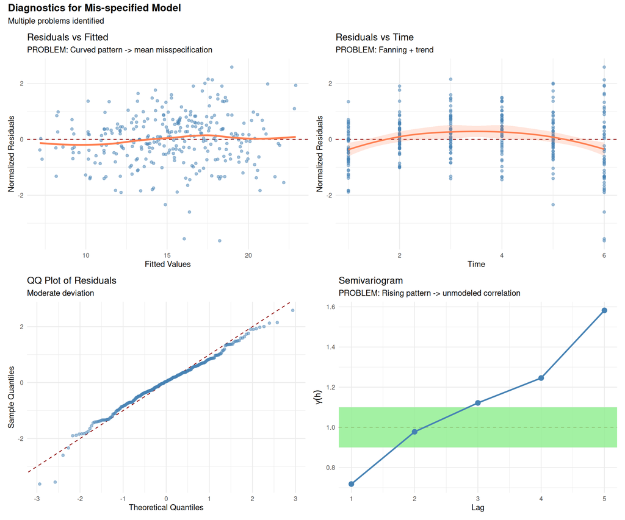

Figure 10: Diagnostic Plots for Mis-specified Model

```r
# Extract diagnostics
problem_data$fitted_bad <- fitted(fit_bad)
problem_data$resid_bad <- resid(fit_bad, type = "normalized")

# 1. Residuals vs Fitted
p1_bad <- ggplot(problem_data, aes(x = fitted_bad, y = resid_bad)) +
  geom_hline(yintercept = 0, linetype = "dashed", color = "darkred") +
  geom_point(alpha = 0.5, color = "steelblue") +
  geom_smooth(method = "loess", se = FALSE, color = "coral", linewidth = 1.2) +
  labs(x = "Fitted Values", y = "Normalized Residuals",
       title = "Residuals vs Fitted",
       subtitle = "PROBLEM: Curved pattern -> mean misspecification") +
  theme_minimal()

# 2. Residuals vs Time
p2_bad <- ggplot(problem_data, aes(x = time, y = resid_bad)) +
  geom_hline(yintercept = 0, linetype = "dashed", color = "darkred") +
  geom_point(alpha = 0.5, color = "steelblue") +
  geom_smooth(method = "loess", se = TRUE, color = "coral", fill = "coral", alpha = 0.2) +
  labs(x = "Time", y = "Normalized Residuals",
       title = "Residuals vs Time",
       subtitle = "PROBLEM: Fanning + trend") +
  theme_minimal()

# 3. QQ Plot of Residuals
qq_bad <- qqnorm(problem_data$resid_bad, plot.it = FALSE)
qq_bad_df <- data.frame(Theoretical = qq_bad$x, Sample = qq_bad$y)

p3_bad <- ggplot(qq_bad_df, aes(x = Theoretical, y = Sample)) +
  geom_abline(slope = 1, intercept = 0, linetype = "dashed", color = "darkred") +
  geom_point(alpha = 0.5, color = "steelblue") +
  labs(x = "Theoretical Quantiles", y = "Sample Quantiles",
       title = "QQ Plot of Residuals",
       subtitle = "Moderate deviation") +
  theme_minimal()

# 4. Semivariogram
vario_bad <- Variogram(fit_bad, form = ~ time | subject, resType = "normalized")

p4_bad <- ggplot(data.frame(vario_bad), aes(x = dist, y = variog)) +
  geom_hline(yintercept = 1, linetype = "dashed", color = "darkred") +
  geom_rect(aes(xmin = -Inf, xmax = Inf, ymin = 0.9, ymax = 1.1),
            fill = "lightgreen", alpha = 0.3) +
  geom_point(color = "steelblue", size = 3) +
  geom_line(color = "steelblue", linewidth = 1) +
  labs(x = "Lag", y = expression(gamma(h)),
       title = "Semivariogram",
       subtitle = "PROBLEM: Rising pattern -> unmodeled correlation") +
  theme_minimal()

(p1_bad + p2_bad) / (p3_bad + p4_bad) +
  plot_annotation(
    title = "Diagnostics for Mis-specified Model",
    subtitle = "Multiple problems identified",
    theme = theme(plot.title = element_text(face = "bold", size = 14))
  )
```

### Step 4: Fit Corrected Model

```r
# Add:
# 1. Quadratic time effect
# 2. AR(1) correlation structure
# 3. Variance function for heteroscedasticity

fit_good <- lme(y ~ time + I(time^2),
                random = ~ 1 | subject,
                correlation = corAR1(form = ~ time | subject),
                weights = varPower(form = ~ time),
                data = problem_data,
                method = "REML")

summary(fit_good)
```

```
Linear mixed-effects model fit by REML
  Data: problem_data
      AIC      BIC  logLik
  1278.74 1304.596 -632.37

Random effects:
 Formula: ~1 | subject
        (Intercept)  Residual
StdDev:    2.905208 0.9205343

Correlation Structure: AR(1)
 Formula: ~time | subject
 Parameter estimate(s):
      Phi
0.4268099
Variance function:
 Structure: Power of variance covariate
 Formula: ~time
 Parameter estimates:
    power
0.5718423
Fixed effects:  y ~ time + I(time^2)
                Value Std.Error  DF   t-value p-value
(Intercept)  9.961763 0.4940096 248 20.165119       0
time         2.381919 0.2442705 248  9.751152       0
I(time^2)   -0.198811 0.0387330 248 -5.132870       0
 Correlation:
          (Intr) time
time      -0.489
I(time^2)  0.437 -0.964

Standardized Within-Group Residuals:
        Min          Q1         Med          Q3         Max
-2.40684848 -0.54714447  0.03968414  0.56814384  2.22716027

Number of Observations: 300
Number of Groups: 50
```

### Step 5: Compare Diagnostics

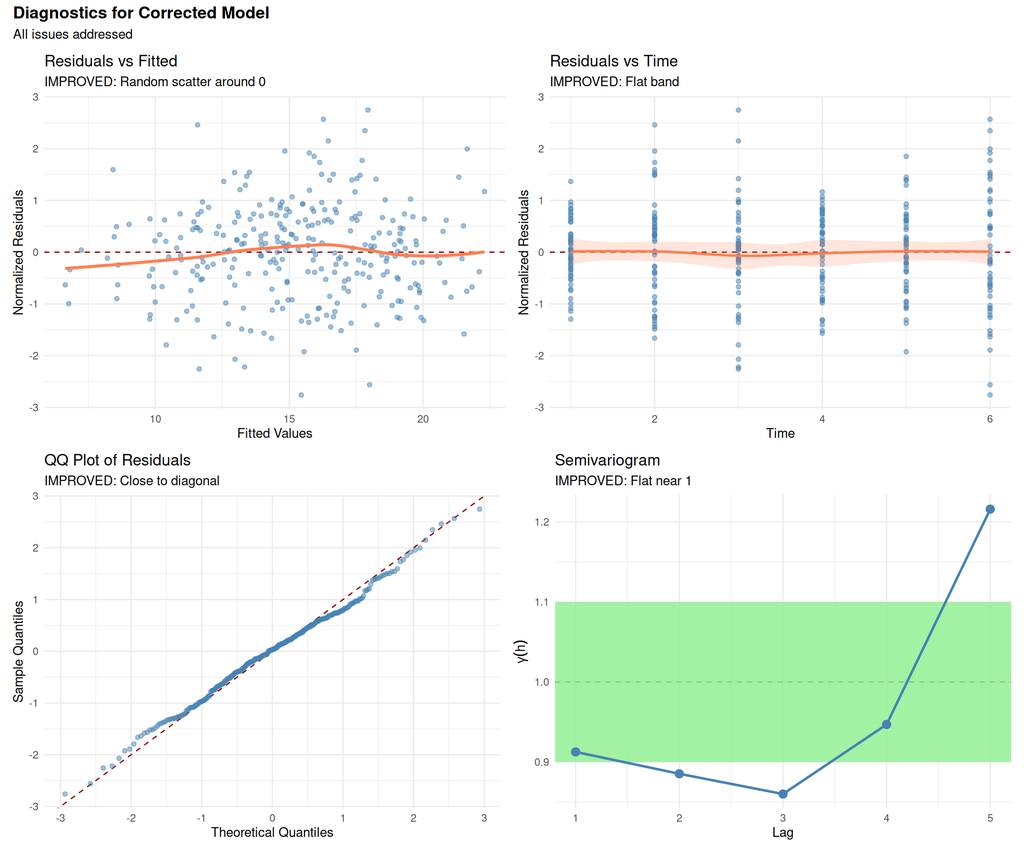

Figure 11: Diagnostic Plots for Corrected Model

```r
# Extract diagnostics for good model
problem_data$fitted_good <- fitted(fit_good)
problem_data$resid_good <- resid(fit_good, type = "normalized")

# 1. Residuals vs Fitted
p1_good <- ggplot(problem_data, aes(x = fitted_good, y = resid_good)) +
  geom_hline(yintercept = 0, linetype = "dashed", color = "darkred") +
  geom_point(alpha = 0.5, color = "steelblue") +
  geom_smooth(method = "loess", se = FALSE, color = "coral", linewidth = 1.2) +
  labs(x = "Fitted Values", y = "Normalized Residuals",
       title = "Residuals vs Fitted",
       subtitle = "IMPROVED: Random scatter around 0") +
  theme_minimal()

# 2. Residuals vs Time
p2_good <- ggplot(problem_data, aes(x = time, y = resid_good)) +
  geom_hline(yintercept = 0, linetype = "dashed", color = "darkred") +
  geom_point(alpha = 0.5, color = "steelblue") +
  geom_smooth(method = "loess", se = TRUE, color = "coral", fill = "coral", alpha = 0.2) +
  labs(x = "Time", y = "Normalized Residuals",
       title = "Residuals vs Time",
       subtitle = "IMPROVED: Flat band") +
  theme_minimal()

# 3. QQ Plot of Residuals
qq_good <- qqnorm(problem_data$resid_good, plot.it = FALSE)
qq_good_df <- data.frame(Theoretical = qq_good$x, Sample = qq_good$y)

p3_good <- ggplot(qq_good_df, aes(x = Theoretical, y = Sample)) +
  geom_abline(slope = 1, intercept = 0, linetype = "dashed", color = "darkred") +
  geom_point(alpha = 0.5, color = "steelblue") +
  labs(x = "Theoretical Quantiles", y = "Sample Quantiles",
       title = "QQ Plot of Residuals",
       subtitle = "IMPROVED: Close to diagonal") +
  theme_minimal()

# 4. Semivariogram
vario_good <- Variogram(fit_good, form = ~ time | subject, resType = "normalized")

p4_good <- ggplot(data.frame(vario_good), aes(x = dist, y = variog)) +
  geom_hline(yintercept = 1, linetype = "dashed", color = "darkred") +
  geom_rect(aes(xmin = -Inf, xmax = Inf, ymin = 0.9, ymax = 1.1),
            fill = "lightgreen", alpha = 0.3) +
  geom_point(color = "steelblue", size = 3) +
  geom_line(color = "steelblue", linewidth = 1) +
  labs(x = "Lag", y = expression(gamma(h)),
       title = "Semivariogram",
       subtitle = "IMPROVED: Flat near 1") +
  theme_minimal()

(p1_good + p2_good) / (p3_good + p4_good) +
  plot_annotation(
    title = "Diagnostics for Corrected Model",
    subtitle = "All issues addressed",
    theme = theme(plot.title = element_text(face = "bold", size = 14))
  )
```

### Step 6: Side-by-Side Comparison

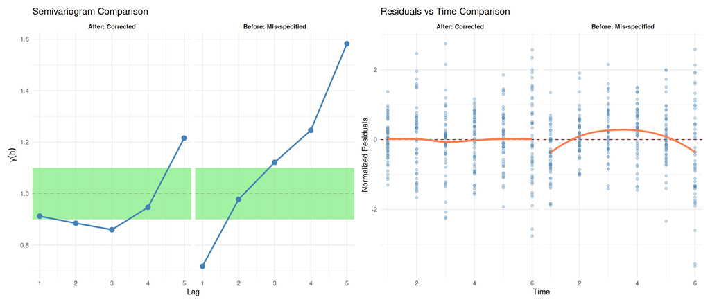

Figure 12: Before and After: Model Improvement Summary

```r
# Combine semivariograms for comparison
vario_compare <- rbind(
  data.frame(vario_bad) |> mutate(Model = "Before: Mis-specified"),
  data.frame(vario_good) |> mutate(Model = "After: Corrected")
)

p_vario_compare <- ggplot(vario_compare, aes(x = dist, y = variog)) +
  geom_hline(yintercept = 1, linetype = "dashed", color = "darkred") +
  geom_rect(aes(xmin = -Inf, xmax = Inf, ymin = 0.9, ymax = 1.1),
            fill = "lightgreen", alpha = 0.3) +
  geom_point(color = "steelblue", size = 3) +
  geom_line(color = "steelblue", linewidth = 1) +
  facet_wrap(~Model) +
  labs(x = "Lag", y = expression(gamma(h)),
       title = "Semivariogram Comparison") +
  theme_minimal() +
  theme(strip.text = element_text(face = "bold"))

# Combine residual plots
resid_compare <- rbind(
  problem_data |>
    select(time, resid = resid_bad) |>
    mutate(Model = "Before: Mis-specified"),
  problem_data |>
    select(time, resid = resid_good) |>
    mutate(Model = "After: Corrected")
)

p_resid_compare <- ggplot(resid_compare, aes(x = time, y = resid)) +
  geom_hline(yintercept = 0, linetype = "dashed", color = "darkred") +
  geom_point(alpha = 0.3, color = "steelblue") +
  geom_smooth(method = "loess", se = FALSE, color = "coral", linewidth = 1.2) +
  facet_wrap(~Model) +
  labs(x = "Time", y = "Normalized Residuals",
       title = "Residuals vs Time Comparison") +
  theme_minimal() +
  theme(strip.text = element_text(face = "bold"))

p_vario_compare + p_resid_compare
```

### Model Comparison Summary

```r
# Compare AIC/BIC
cat("Model Comparison:\n")
```

```
Model Comparison:
```

```r
cat("================\n\n")
cat("Mis-specified Model (y ~ time, random intercept only):\n")
```

```
Mis-specified Model (y ~ time, random intercept only):
```

```r
cat("  AIC:", round(AIC(fit_bad), 2), "\n")
```

```
  AIC: 1345.4
```

```r
cat("  BIC:", round(BIC(fit_bad), 2), "\n\n")
```

```
  BIC: 1360.19
```

```r
cat("Corrected Model (y ~ time + time^2, AR(1), varPower):\n")
```

```
Corrected Model (y ~ time + time^2, AR(1), varPower):
```

```r
cat("  AIC:", round(AIC(fit_good), 2), "\n")
```

```
  AIC: 1278.74
```

```r
cat("  BIC:", round(BIC(fit_good), 2), "\n\n")
```

```
  BIC: 1304.6
```

```r
cat("Improvement:\n")
```

```
Improvement:
```

```r
cat("  Delta AIC:", round(AIC(fit_bad) - AIC(fit_good), 2), "(positive = corrected model better)\n")
```

```
  Delta AIC: 66.66 (positive = corrected model better)
```

```r
cat("  Delta BIC:", round(BIC(fit_bad) - BIC(fit_good), 2), "\n\n")
```

```
  Delta BIC: 55.59
```

```r
cat("Estimated AR(1) correlation:\n")
```

```
Estimated AR(1) correlation:
```

```r
cat("  phi =", round(coef(fit_good$modelStruct$corStruct, unconstrained = FALSE), 3), "\n")
```

```
  phi = 0.427
```

```r
cat("\nEstimated variance power:\n")
```

```
Estimated variance power:
```

```r
cat("  delta =", round(coef(fit_good$modelStruct$varStruct, unconstrained = FALSE), 3), "\n")
```

```
  delta = 0.572
```

## Summary: Diagnostic Checklist

Use this checklist when validating your longitudinal models:

### Residuals vs Fitted

- Random scatter around 0
- No funnel shape (heteroscedasticity)
- No curved pattern (mean misspecification)

### Residuals vs Time

- Flat band across time
- No fanning (would suggest random slopes)
- No trend (would suggest missing time effect)

### QQ Plot of Residuals

- Points approximately on diagonal
- No severe S-shape (heavy tails)
- No strong curvature (skewness)

### QQ Plot of Random Effects

- Roughly on line (some deviation OK)
- No extreme outliers suggesting mixture

### Semivariogram

- Flat near 1 across all lags
- No rising pattern (would need AR structure)
- Values do not exceed 1 substantially

### ACF of Residuals

- All bars within blue confidence bands
- No significant correlation at lag 1+
- No systematic pattern

### Influence Diagnostics

- No observations with Cook’s D > 4/n
- DFBETAS within bounds for key coefficients
- Any influential points investigated

## Quick Reference Code

```r
# Fit your model
fit <- lme(y ~ time * treatment,
           random = ~ 1 | subject,
           correlation = corAR1(form = ~ time | subject),
           data = mydata)

# Extract residuals
mydata$resid_norm <- resid(fit, type = "normalized")
mydata$fitted <- fitted(fit)

# 1. Residuals vs Fitted
plot(fitted(fit), resid(fit, type = "normalized"))
abline(h = 0, lty = 2)

# 2. Residuals vs Time
plot(mydata$time, mydata$resid_norm)
abline(h = 0, lty = 2)

# 3. QQ Plot of Residuals
qqnorm(resid(fit, type = "normalized"))
qqline(resid(fit, type = "normalized"))

# 4. QQ Plot of Random Effects
qqnorm(ranef(fit)$`(Intercept)`)
qqline(ranef(fit)$`(Intercept)`)

# 5. Semivariogram
plot(Variogram(fit, form = ~ time | subject, resType = "normalized"))

# 6. ACF of Residuals (by subject, then average)
acf(resid(fit, type = "normalized"))

# 7. Influence (requires additional packages)
library(influence.ME)
influence_fit <- influence(fit, group = "subject")
cooks.distance(influence_fit)
```

## Further Reading

- See **Semivariogram Guide** for detailed interpretation of semivariograms
- See **Covariance Structure Selection** for choosing correlation structures
- Pinheiro, J.C. and Bates, D.M. (2000). *Mixed-Effects Models in S and S-PLUS*
- Fitzmaurice, G.M., Laird, N.M., and Ware, J.H. (2011). *Applied Longitudinal Analysis*